# DAT205x: Introduction to Data Analysis using R. Lab3b

# Scenario

Now you can start adding some charts.

Load libraries

```r
library(tidyverse)
library(scales)
library(RColorBrewer)
```

Load data for Lab3b

```r
my_data <- readRDS("./week2/data4week3.rds")
```

Add a chart that shows yearly **Sales by Country**. Select a line chart to display the yearly trend. Make sure that the Years are located in the X axis, the **Revenue** in the Y axis, and the **Countries** as categories.

In this chart, you can clearly see the sales trend for each **Country**.

#### **Question 1:** Which country’s trend is the most different when compared to the other countries?

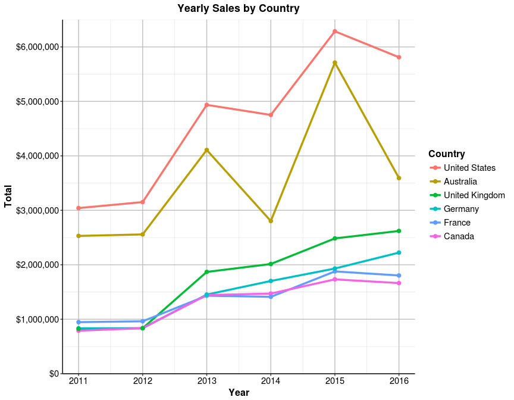

#### **Answer:** Australia

#### **Question 2:** Which year does the Bikes category have the least sales?

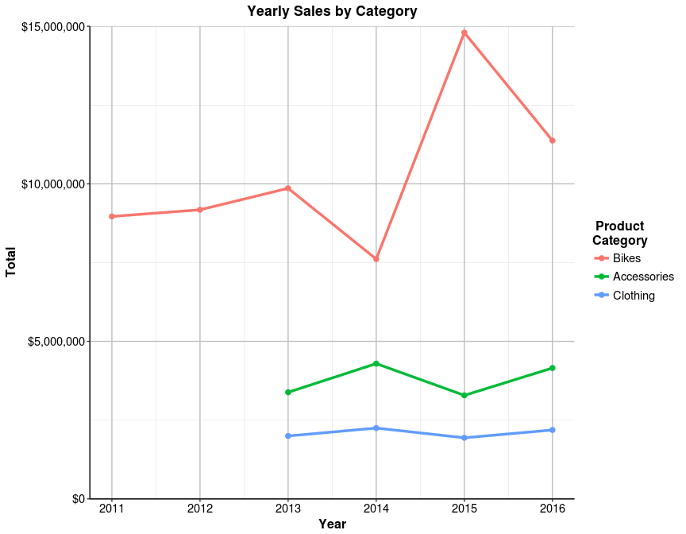

#### **Answer:** 2014

Add another pivot chart, this time for the pivot table that shows **Revenue** by **Age Group**. Select a pie chart to display the proportion of each **Age Group**. Add the labels to show percentage, formatted to two decimal points.

```r
ans_3 <- my_data %>%
    group_by(`Age Group`) %>%
    summarise(Total = sum(Revenue)) %>%
    arrange(Total) %>%
    mutate(Prop = formatC(Total / sum(Total), digits = 4, format = "f") %>%
               as.numeric(),
           Percent = paste(Prop * 100, "%"),
           y_tick = cumsum(Prop) - Prop / 2)
ans_3$`Age Group` <- factor(ans_3$`Age Group`,
                                      levels = ans_3$`Age Group`)
```

In this chart, we can clearly see the proportion of sales for each **Age Group**.

#### **Question 3:** What is the proportion of sales for Young Adults?

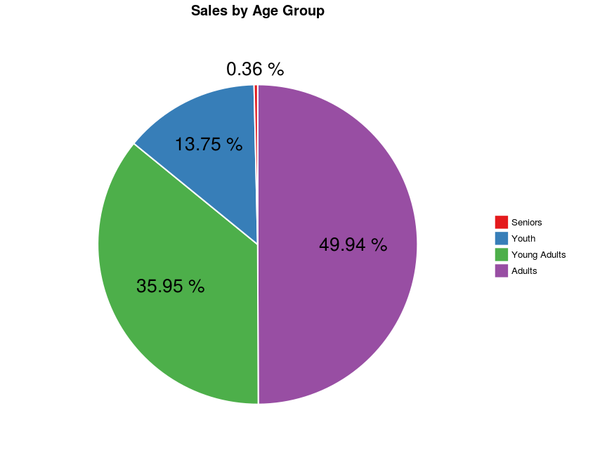

#### **Answer:** 35.95 %

Add another pivot chart, this time for the pivot table that shows **Revenue** by **Frame size**. Select a bar chart to display the order of sales by **Frame size**. Sort the Y axis to show the **Frame size** that has the most sales on the top.

```r
ans_4 <- my_data %>%
    filter(!is.na(`Frame Size`)) %>%
    group_by(`Frame Size`) %>%
    summarise(`Total Revenue` = sum(Revenue)) %>%
    arrange(`Total Revenue`)
```

#### **Question 4:** In this chart, you can clearly see the order of sales by Frame size. Which frame size sold the least?

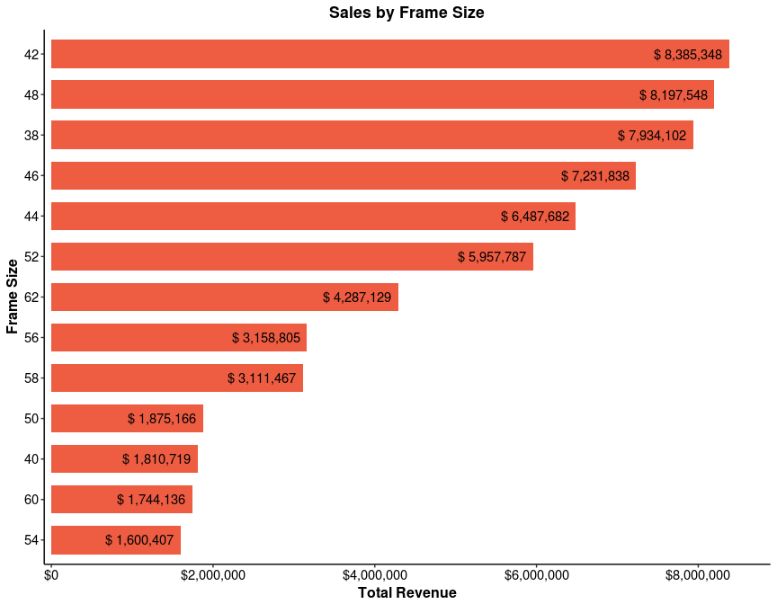

#### **Answer:** 54